# 处理缺失数据的高级方法

Studennt. LI Junjie

Dongbei University of Finance & Economics

2020-07-11

# 1 加载经常用的R包

```r
library(pacman)
# 读数据
p_load(readxl,writexl,data.table,openxlsx,haven,rvest)
```

```r
# 数据探索
p_load(tidyverse,DT,skimr,DataExplorer,explore,vtable,stringr,kableExtra,lubridate)
```

```r
# 模型
p_load(grf,glmnet,caret,tidytext,fpp2,forecast,car,tseries,hdm,tidymodels,broom)
```

```r
# 可视化
p_load(patchwork,ggrepel,ggcorrplot,gghighlight,ggthemes,shiny)
```

```r
# 其它常用包
p_load(magrittr,listviewer,devtools,here,janitor,reticulate,jsonlite)
```

大部分人都想在一定程度上避免缺失数据造成的影响。统计教科书可能不会提及这个问题， 或者仅用很少的篇幅介绍；统计软件提供的自动处理缺失值的方法也可能不是最优的。虽然多数数据分析（至少在社会科学中）会牵涉缺失数据，但在期刊文章的方法和结果章节却极少讨论这个问题。鉴于缺失值常常出现，并且可能导致研究结果在一定程度上无效，可以说除了在一些专业化的书籍和课程中，这个问题的受重视程度还远远不够。

本章中，我们将学习处理缺失数据的传统方法和现代方法，主要使用VIM和mice包。命令 install.packages(c(“VIM”,“mice”))可下载并安装这两个软件包。

# 2 处理缺失值的步骤

统计学家通常将缺失数据分为三类。尽管它们都用概率术语进行描述，但思想都非常直观。我们将用sleep研究中对做梦时长的测量（12种动物有缺失值）来依次阐述三种类型。

1. **完全随机缺失**: 若某变量的缺失数据与其他任何观测或未观测变量都不相关，则数据为完全随机缺失（MCAR）。若12种动物的做梦时长值缺失不是出于系统原因，那么可以认为数据是MCAR。注意，如果每个有缺失值的变量都是MCAR，那么可以将数据完整的实例看作对更大数据集的一个简单随机抽样。
2. **随机缺失**: 若某变量上的缺失数据与其他观测变量相关，与它自己的未观测值不相关，则数据为随机缺失（MAR）。例如，如果体重较小的动物更可能有做梦时长的缺失值（可能因为较小的动物更难观察），而且该“缺失”与动物的做梦时长无关，那么就可以认为该数据是MAR。此时，一旦控制了体重变量，做梦时长数据的缺失与出现将是随机的。
3. **非随机缺失**: 若缺失数据不属于MCAR和MAR，则数据为非随机缺失（NMAR） 。例如，做梦时长越短的动物更可能有做梦数据的缺失（可能由于难以测量时长较短的事件），那么可认为数据是NMAR。大部分处理缺失数据的方法都假定数据是MCAR或MAR。此时，你可以忽略缺失数据的生成机制，并且（在替换或删除缺失数据后）可以直接对感兴趣的关系进行建模。

```r
p_load(VIM,mice)
sleep
```

| BodyWgt | BrainWgt | NonD | Dream | Sleep | Span | Gest | Pred | Exp | Danger |
| --- | --- | --- | --- | --- | --- | --- | --- | --- | --- |
| 6654.000 | 5712.00 | NA | NA | 3.3 | 38.6 | 645.0 | 3 | 5 | 3 |
| 1.000 | 6.60 | 6.3 | 2.0 | 8.3 | 4.5 | 42.0 | 3 | 1 | 3 |
| 3.385 | 44.50 | NA | NA | 12.5 | 14.0 | 60.0 | 1 | 1 | 1 |
| 0.920 | 5.70 | NA | NA | 16.5 | NA | 25.0 | 5 | 2 | 3 |
| 2547.000 | 4603.00 | 2.1 | 1.8 | 3.9 | 69.0 | 624.0 | 3 | 5 | 4 |
| 10.550 | 179.50 | 9.1 | 0.7 | 9.8 | 27.0 | 180.0 | 4 | 4 | 4 |
| 0.023 | 0.30 | 15.8 | 3.9 | 19.7 | 19.0 | 35.0 | 1 | 1 | 1 |
| 160.000 | 169.00 | 5.2 | 1.0 | 6.2 | 30.4 | 392.0 | 4 | 5 | 4 |
| 3.300 | 25.60 | 10.9 | 3.6 | 14.5 | 28.0 | 63.0 | 1 | 2 | 1 |
| 52.160 | 440.00 | 8.3 | 1.4 | 9.7 | 50.0 | 230.0 | 1 | 1 | 1 |

[output cut: 52 more lines]

```r
VIM::sleep %>% is.na()
```

```
##       BodyWgt BrainWgt  NonD Dream Sleep  Span  Gest  Pred   Exp Danger
##  [1,]   FALSE    FALSE  TRUE  TRUE FALSE FALSE FALSE FALSE FALSE  FALSE
##  [2,]   FALSE    FALSE FALSE FALSE FALSE FALSE FALSE FALSE FALSE  FALSE
##  [3,]   FALSE    FALSE  TRUE  TRUE FALSE FALSE FALSE FALSE FALSE  FALSE
##  [4,]   FALSE    FALSE  TRUE  TRUE FALSE  TRUE FALSE FALSE FALSE  FALSE
##  [5,]   FALSE    FALSE FALSE FALSE FALSE FALSE FALSE FALSE FALSE  FALSE
##  [6,]   FALSE    FALSE FALSE FALSE FALSE FALSE FALSE FALSE FALSE  FALSE
##  [7,]   FALSE    FALSE FALSE FALSE FALSE FALSE FALSE FALSE FALSE  FALSE
##  [8,]   FALSE    FALSE FALSE FALSE FALSE FALSE FALSE FALSE FALSE  FALSE
##  [9,]   FALSE    FALSE FALSE FALSE FALSE FALSE FALSE FALSE FALSE  FALSE
## [10,]   FALSE    FALSE FALSE FALSE FALSE FALSE FALSE FALSE FALSE  FALSE
## [11,]   FALSE    FALSE FALSE FALSE FALSE FALSE FALSE FALSE FALSE  FALSE
## [12,]   FALSE    FALSE FALSE FALSE FALSE FALSE FALSE FALSE FALSE  FALSE
## [13,]   FALSE    FALSE FALSE FALSE FALSE  TRUE  TRUE FALSE FALSE  FALSE
## [14,]   FALSE    FALSE  TRUE  TRUE FALSE FALSE FALSE FALSE FALSE  FALSE
```

[output cut: 48 more lines]

```r
sleep %>% complete.cases()
```

```
##  [1] FALSE  TRUE FALSE FALSE  TRUE  TRUE  TRUE  TRUE  TRUE  TRUE  TRUE  TRUE
## [13] FALSE FALSE  TRUE  TRUE  TRUE  TRUE FALSE FALSE FALSE  TRUE  TRUE FALSE
## [25]  TRUE FALSE  TRUE  TRUE  TRUE FALSE FALSE  TRUE  TRUE  TRUE FALSE FALSE
## [37]  TRUE  TRUE  TRUE  TRUE FALSE  TRUE  TRUE  TRUE  TRUE  TRUE FALSE  TRUE
## [49]  TRUE  TRUE  TRUE  TRUE FALSE  TRUE FALSE FALSE  TRUE  TRUE  TRUE  TRUE
## [61]  TRUE FALSE
```

要完整介绍处理缺失数据的方法，用一本书的篇幅才能做到。本章，我们只是**学习探究缺失值模式的方法**，并重点介绍三种最流行的处理不完整数据的方法（推理法、行删除法和多重插补法）。在本章最后，我们还将介绍一些在特定环境中非常有用的其他处理办法。

# 3 识别缺失值

首先，回顾4.5节的内容并进一步拓展。R使用NA（不可得）代表缺失值，NaN（不是一个数）代表不可能值。另外，符号Inf和-Inf分别代表正无穷和负无穷。函数is.na()、is.nan()和is.infinite()可分别用来识别缺失值、不可能值和无穷值。每个返回结果都是TRUE或FALSE。

```r
sleep$Sleep %>% is.na()
```

```
##  [1] FALSE FALSE FALSE FALSE FALSE FALSE FALSE FALSE FALSE FALSE FALSE FALSE
## [13] FALSE FALSE FALSE FALSE FALSE FALSE FALSE FALSE  TRUE FALSE FALSE FALSE
## [25] FALSE FALSE FALSE FALSE FALSE FALSE  TRUE FALSE FALSE FALSE FALSE FALSE
## [37] FALSE FALSE FALSE FALSE  TRUE FALSE FALSE FALSE FALSE FALSE FALSE FALSE
## [49] FALSE FALSE FALSE FALSE FALSE FALSE FALSE FALSE FALSE FALSE FALSE FALSE
## [61] FALSE  TRUE
```

完整行数

```r
sleep[complete.cases(sleep),]
```

|  | BodyWgt | BrainWgt | NonD | Dream | Sleep | Span | Gest | Pred | Exp | Danger |
| --- | --- | --- | --- | --- | --- | --- | --- | --- | --- | --- |
| 2 | 1.000 | 6.60 | 6.3 | 2.0 | 8.3 | 4.5 | 42.0 | 3 | 1 | 3 |
| 5 | 2547.000 | 4603.00 | 2.1 | 1.8 | 3.9 | 69.0 | 624.0 | 3 | 5 | 4 |
| 6 | 10.550 | 179.50 | 9.1 | 0.7 | 9.8 | 27.0 | 180.0 | 4 | 4 | 4 |
| 7 | 0.023 | 0.30 | 15.8 | 3.9 | 19.7 | 19.0 | 35.0 | 1 | 1 | 1 |
| 8 | 160.000 | 169.00 | 5.2 | 1.0 | 6.2 | 30.4 | 392.0 | 4 | 5 | 4 |
| 9 | 3.300 | 25.60 | 10.9 | 3.6 | 14.5 | 28.0 | 63.0 | 1 | 2 | 1 |
| 10 | 52.160 | 440.00 | 8.3 | 1.4 | 9.7 | 50.0 | 230.0 | 1 | 1 | 1 |
| 11 | 0.425 | 6.40 | 11.0 | 1.5 | 12.5 | 7.0 | 112.0 | 5 | 4 | 4 |
| 12 | 465.000 | 423.00 | 3.2 | 0.7 | 3.9 | 30.0 | 281.0 | 5 | 5 | 5 |
| 15 | 0.075 | 1.20 | 6.3 | 2.1 | 8.4 | 3.5 | 42.0 | 1 | 1 | 1 |

[output cut: 32 more lines]

```r
complete.cases(sleep)
```

```
##  [1] FALSE  TRUE FALSE FALSE  TRUE  TRUE  TRUE  TRUE  TRUE  TRUE  TRUE  TRUE
## [13] FALSE FALSE  TRUE  TRUE  TRUE  TRUE FALSE FALSE FALSE  TRUE  TRUE FALSE
## [25]  TRUE FALSE  TRUE  TRUE  TRUE FALSE FALSE  TRUE  TRUE  TRUE FALSE FALSE
## [37]  TRUE  TRUE  TRUE  TRUE FALSE  TRUE  TRUE  TRUE  TRUE  TRUE FALSE  TRUE
## [49]  TRUE  TRUE  TRUE  TRUE FALSE  TRUE FALSE FALSE  TRUE  TRUE  TRUE  TRUE
## [61]  TRUE FALSE
```

缺失值的行

```r
sleep[!complete.cases(sleep),]
```

|  | BodyWgt | BrainWgt | NonD | Dream | Sleep | Span | Gest | Pred | Exp | Danger |
| --- | --- | --- | --- | --- | --- | --- | --- | --- | --- | --- |
| 1 | 6654.000 | 5712.0 | NA | NA | 3.3 | 38.6 | 645 | 3 | 5 | 3 |
| 3 | 3.385 | 44.5 | NA | NA | 12.5 | 14.0 | 60 | 1 | 1 | 1 |
| 4 | 0.920 | 5.7 | NA | NA | 16.5 | NA | 25 | 5 | 2 | 3 |
| 13 | 0.550 | 2.4 | 7.6 | 2.7 | 10.3 | NA | NA | 2 | 1 | 2 |
| 14 | 187.100 | 419.0 | NA | NA | 3.1 | 40.0 | 365 | 5 | 5 | 5 |
| 19 | 1.410 | 17.5 | 4.8 | 1.3 | 6.1 | 34.0 | NA | 1 | 2 | 1 |
| 20 | 60.000 | 81.0 | 12.0 | 6.1 | 18.1 | 7.0 | NA | 1 | 1 | 1 |
| 21 | 529.000 | 680.0 | NA | 0.3 | NA | 28.0 | 400 | 5 | 5 | 5 |
| 24 | 207.000 | 406.0 | NA | NA | 12.0 | 39.3 | 252 | 1 | 4 | 1 |
| 26 | 36.330 | 119.5 | NA | NA | 13.0 | 16.2 | 63 | 1 | 1 | 1 |

[output cut: 10 more lines]

```r
sleep$Dream %>% is.na() %>% sum()
```

```
## [1] 12
```

对于识别缺失值，有两点需要牢记。第一，`complete.cases()函数`仅将NA和NaN识别为缺失值，无穷值（Inf和-Inf）被当作有效值。第二，必须使用与本章中类似的缺失值函数来识别R数据对象中的缺失值。像`myvar == NA`这样的逻辑比较无法实现。

现在你应该懂得了如何用程序识别缺失值，接下来学习一些有助于发现缺失值模式的工具吧。

# 4 探索缺失值模式

## 4.1 列表显示缺失值

```r
sleep %>% skim()
```

Table 4.1: Data summary

| Name | Piped data |
| --- | --- |
| Number of rows | 62 |
| Number of columns | 10 |
| _______________________ |  |
| Column type frequency: |  |
| numeric | 10 |
| ________________________ |  |
| Group variables | None |

**Variable type: numeric**

| skim_variable | n_missing | complete_rate | mean | sd | p0 | p25 | p50 | p75 | p100 | hist |
| --- | --- | --- | --- | --- | --- | --- | --- | --- | --- | --- |
| BodyWgt | 0 | 1.00 | 198.79 | 899.16 | 0.00 | 0.60 | 3.34 | 48.20 | 6654.0 | ▇▁▁▁▁ |
| BrainWgt | 0 | 1.00 | 283.13 | 930.28 | 0.14 | 4.25 | 17.25 | 166.00 | 5712.0 | ▇▁▁▁▁ |
| NonD | 14 | 0.77 | 8.67 | 3.67 | 2.10 | 6.25 | 8.35 | 11.00 | 17.9 | ▅▇▆▃▂ |
| Dream | 12 | 0.81 | 1.97 | 1.44 | 0.00 | 0.90 | 1.80 | 2.55 | 6.6 | ▇▇▃▁▁ |
| Sleep | 4 | 0.94 | 10.53 | 4.61 | 2.60 | 8.05 | 10.45 | 13.20 | 19.9 | ▅▅▇▃▃ |
| Span | 4 | 0.94 | 19.88 | 18.21 | 2.00 | 6.62 | 15.10 | 27.75 | 100.0 | ▇▃▁▁▁ |
| Gest | 4 | 0.94 | 142.35 | 146.81 | 12.00 | 35.75 | 79.00 | 207.50 | 645.0 | ▇▃▁▁▁ |
| Pred | 0 | 1.00 | 2.87 | 1.48 | 1.00 | 2.00 | 3.00 | 4.00 | 5.0 | ▇▇▆▃▇ |
| Exp | 0 | 1.00 | 2.42 | 1.60 | 1.00 | 1.00 | 2.00 | 4.00 | 5.0 | ▇▃▁▂▃ |
| Danger | 0 | 1.00 | 2.61 | 1.44 | 1.00 | 1.00 | 2.00 | 4.00 | 5.0 | ▇▆▅▅▃ |

```r
sleep %>% complete.cases() %>% sleep[.,]
```

|  | BodyWgt | BrainWgt | NonD | Dream | Sleep | Span | Gest | Pred | Exp | Danger |
| --- | --- | --- | --- | --- | --- | --- | --- | --- | --- | --- |
| 2 | 1.000 | 6.60 | 6.3 | 2.0 | 8.3 | 4.5 | 42.0 | 3 | 1 | 3 |
| 5 | 2547.000 | 4603.00 | 2.1 | 1.8 | 3.9 | 69.0 | 624.0 | 3 | 5 | 4 |
| 6 | 10.550 | 179.50 | 9.1 | 0.7 | 9.8 | 27.0 | 180.0 | 4 | 4 | 4 |
| 7 | 0.023 | 0.30 | 15.8 | 3.9 | 19.7 | 19.0 | 35.0 | 1 | 1 | 1 |
| 8 | 160.000 | 169.00 | 5.2 | 1.0 | 6.2 | 30.4 | 392.0 | 4 | 5 | 4 |
| 9 | 3.300 | 25.60 | 10.9 | 3.6 | 14.5 | 28.0 | 63.0 | 1 | 2 | 1 |
| 10 | 52.160 | 440.00 | 8.3 | 1.4 | 9.7 | 50.0 | 230.0 | 1 | 1 | 1 |
| 11 | 0.425 | 6.40 | 11.0 | 1.5 | 12.5 | 7.0 | 112.0 | 5 | 4 | 4 |
| 12 | 465.000 | 423.00 | 3.2 | 0.7 | 3.9 | 30.0 | 281.0 | 5 | 5 | 5 |
| 15 | 0.075 | 1.20 | 6.3 | 2.1 | 8.4 | 3.5 | 42.0 | 1 | 1 | 1 |

[output cut: 32 more lines]

mice包中的`md.pattern()函数`可生成一个以矩阵或数据框形式展示缺失值模式的表格。将函数应用到sleep数据集，

```r
is.na(sleep) %>% sum()
```

```
## [1] 38
```

```r
mice::md.pattern(sleep)
```

```
##    BodyWgt BrainWgt Pred Exp Danger Sleep Span Gest Dream NonD
## 42       1        1    1   1      1     1    1    1     1    1  0
## 9        1        1    1   1      1     1    1    1     0    0  2
## 3        1        1    1   1      1     1    1    0     1    1  1
## 2        1        1    1   1      1     1    0    1     1    1  1
## 1        1        1    1   1      1     1    0    1     0    0  3
## 1        1        1    1   1      1     1    0    0     1    1  2
## 2        1        1    1   1      1     0    1    1     1    0  2
## 2        1        1    1   1      1     0    1    1     0    0  3
##          0        0    0   0      0     4    4    4    12   14 38
```

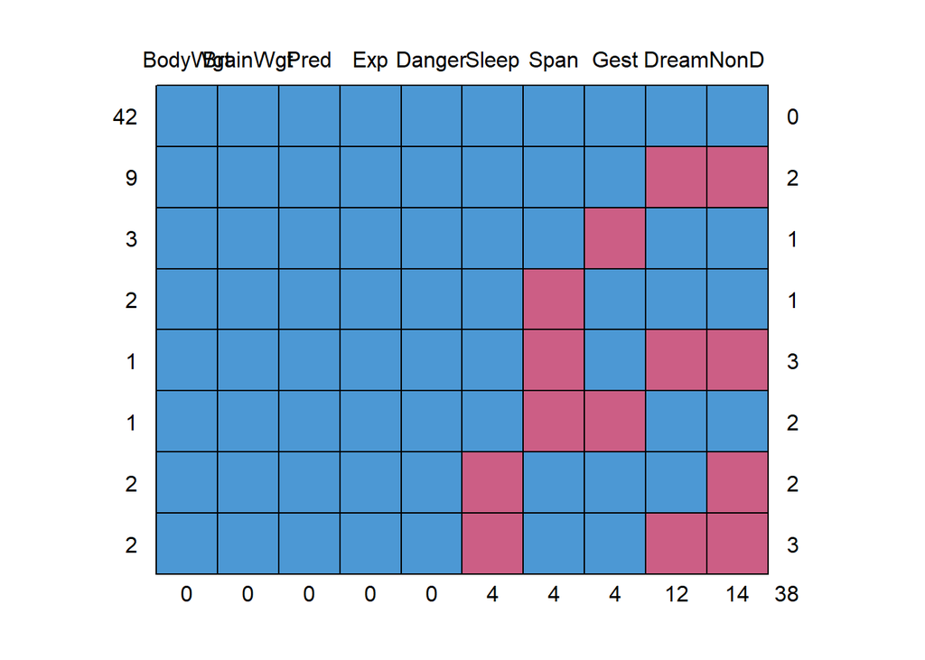

## 4.2 图形探究缺失数据

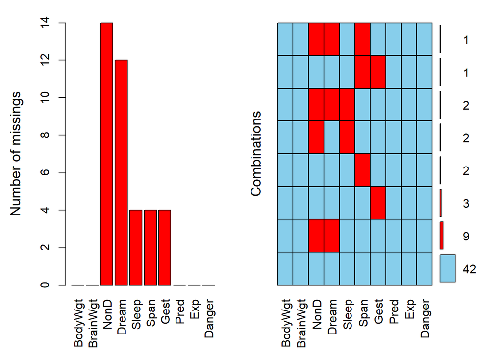

```r
aggr(sleep, prop=FALSE, numbers=TRUE)
```

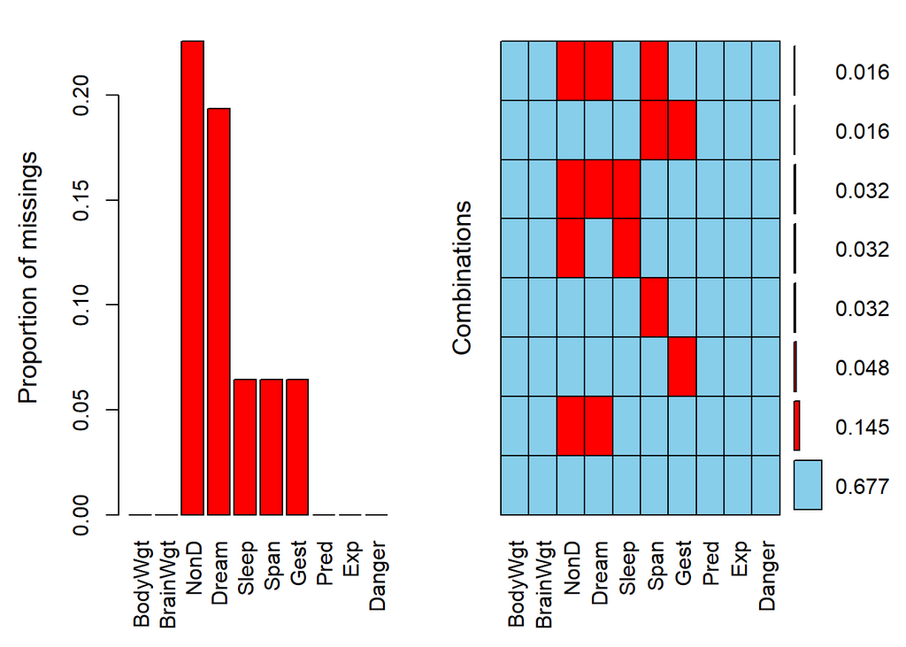

```r
aggr(sleep, prop=TRUE, numbers=TRUE)
```

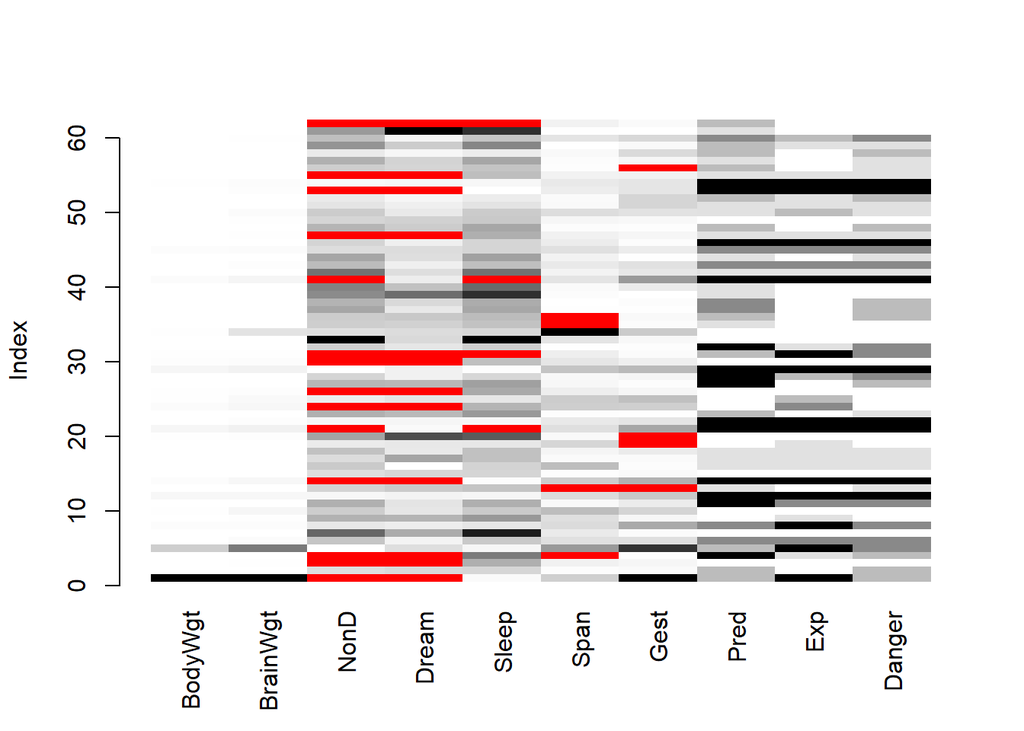

```r
matrixplot(sleep)
```

`marginplot()函`数可生成一幅散点图，在图形边界展示两个变量的缺失值信息。以做梦时长与哺乳动物妊娠期时长的关系为例，来看下列代码：

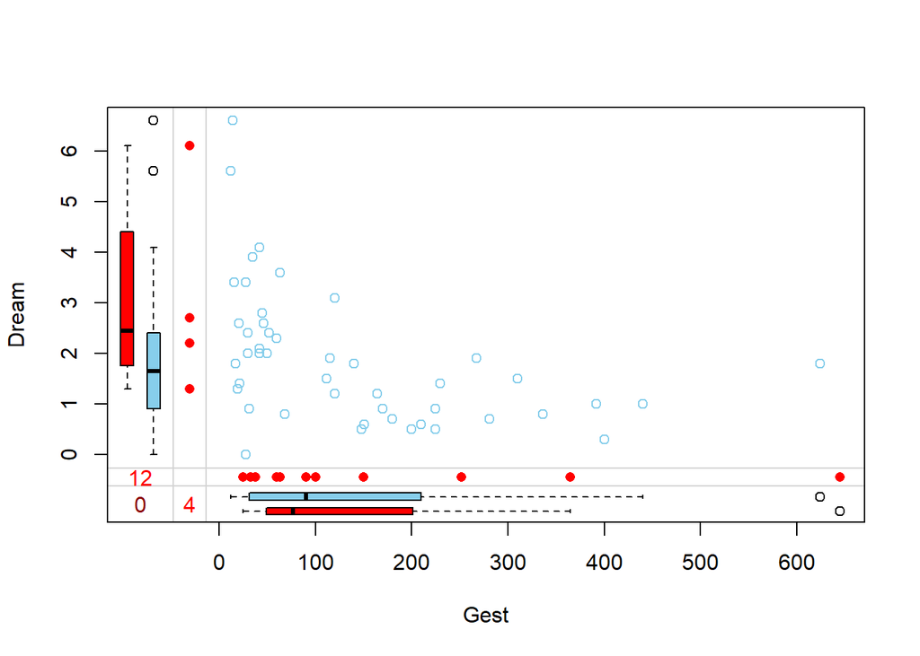

```r
marginplot(sleep[c("Gest","Dream")])
```

## 4.3 用相关性探索缺失值

# 5 理解缺失数据的来由和影响

# 6 理性处理不完整数据

# 7 完整实例分析（行删除）

# 8 多重插补

# 9 处理缺失值的其他方法

虽然**成对删除**似乎利用了所有可用数据，但实际上每次计算都只用了不同的数据子集。这将会导致一些扭曲的、难以解释的结果，所以我建议不要使用该方法。

**简单插补**的一个优点是，解决“缺失值问题”时不会减少分析过程中可用的样本量。虽然简单插补用法很简单，但是对于**非MCAR的数据**会产生有偏的结果。若缺失数据的数目非常大，那么简单插补很可能会低估标准差、曲解变量间的相关性，**并会生成不正确的统计检验的p值**。与成对删除一样，我建议在解决缺失数据的问题时尽量避免使用该方法。